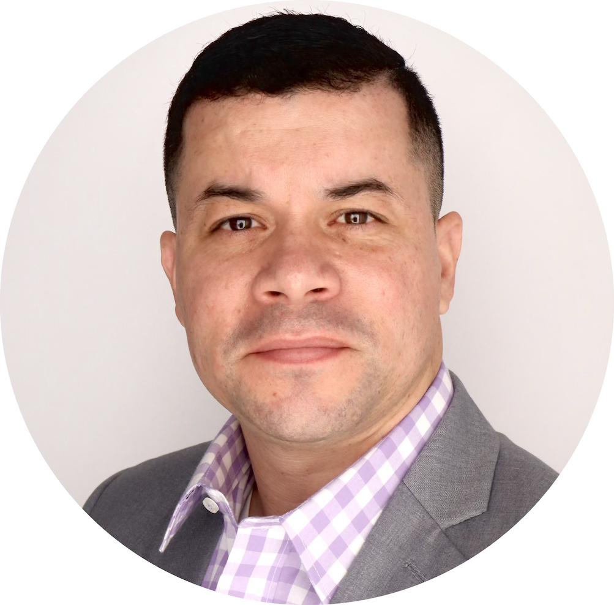

# Oscar Cardec

### Welcome to my Portfolio!

#### Bio

Lead Data Scientist, United States Air Force Veteran and Cyber Intelligence Analyst with an active security clearance and over 20+ years of proven experience managing operations, personnel, and resources, adhering to, and enforcing standards and regulations, and balancing multiple projects while still maintaining a focus on providing quality results. Possess a comprehensive background knowledge in machine learning and predictive analytics, intelligence analysis, management, strategic planning, and cyber intelligence domain derived from steering domestic and global operations in support of the Department of Defense and the Intelligence Community.

#### Education

University of Maryland | Adelphi, MD - MS in Data Analytics  
American Military University | Charles Town, WV - BS in Information Technology Management

#### Experience

GovCIO | Data Scientist - ML Specialist | 2023 - Present  
Deloitte & Touche, LLC | Lead Data Scientist | 2021 - 2023  
Accenture Federal Services | Data Science Intern | 2020 - 2021  
US Air Force | Manager, Intelligence Analyst | 2013 - 2020  
US Air Force | Information & Database Administrator | 2007 - 2013  
US Air Force | Aerospace Maintenance Craftsman | 2000 - 2007

CAO: Jun’23